# Mappa

*Note sulla Pianta de Rovigo (quella vera)*

*(Pagina strappata dal taccuino di Tarcisio – con macchie d’umidità e vino nero)*

**1. Corte Malora**

Una manciata de case senza tempo, su terra molle, in mezzo al niente. Non risulta su nessuna mappa recente, ma i sassi ghe xe ancora. Là, se sussurra forte anche se non ghe xe nessuno a parlare.

**2. Tangenziale Ovest (tratto dismesso)**

Vecchio ramo asfaltà e poi abbandonà. Le carreggiate si piegano in modo sbagliato, come se qualcosa le avesse storte da sotto. Di giorno pare silenziosa, ma non la è mai del tutto.

**3. Vicolo Bàsico**

Appare solo dopo certe curve fatte a piedi. Non compare su Google. I muri si piegano come se respirassero. Chi passa di lì… non dovrebbe fermarsi a guardare troppo.

**4. Campo delle Campane**

Un campo vuoto, ma l’aria trema ogni tanto, come se una campana suonasse dentro le ossa. Nessun edificio attorno, solo vento e erba che non cresce mai tutta uguale.

**5. L’Albero Grando (detto “dei Documenti”)**

Sta nel margine est della città. Troppo grande per esser vero, troppo solo per non essere notato. Ha radici che si spingono sotto la ferrovia e rami che sembrano voler toccare i fili della luce.

**6. Il Canale che No Sta Fermo**

Va, ma non resta. Se lo vedi una volta, il giorno dopo non è più lì. Scorre in modo storto, a tratti controvento. L’acqua pare fredda anche in agosto.

*“Mi no so se Rovigo la xe maledetta o solo dimenticada. Ma ogni volta che torno a guardar la mappa… ghe manca qualcosa.”*

*— Tarcisio*

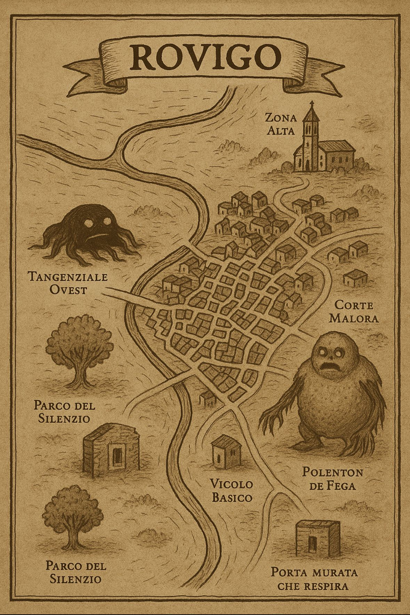